# **第八章：群落多样性分析**

本章内容简介：

- 8.1 目标
- 8.2 关于多样性的介绍
- 8.3 与空间相关的多样性: Alpha, Beta and Gamma 多样性
- 8.4 β-多样性(Beta Diversity)
- 8.5 群落的功能性多样性 & 功能性组成 & 系统进化多样性
- 8.6 结论

## 8.1 目标

- 获取生态学中多样性的基本概念
- 通过多种方式计算 α-物种多样性
- 探索 β-多样性 的概念
- 将 β-多样性 划分为局部和物种贡献
- 将 β-多样性 划分为替换、丰富度差异和嵌套
- 简要介绍功能多样性的概念

## 8.2 关于多样性的介绍

### 8.2.1 简介

基于分类学多样性研究群落水平的物种多样性. [Biodiversity & Human Well-being](https://www.greenfacts.org/en/biodiversity/l-3/1-define-biodiversity.htm) Biodiversity [Ecosystem biodiversity](https://www.khanacademy.org/science/high-school-biology/hs-ecology/hs-community-ecology/v/ecosystem-biodiversity) [Microbial Diversity](https://pdfs.semanticscholar.org/f2d9/70d4ca8a5069cf95df1da44322dcaa01353a.pdf) [MICROBIAL DIVERSITY - book](http://downloads.lww.com/wolterskluwer_vitalstream_com/sample-content/9781605476735_engelkirk/samples/chapter04.pdf)

### 8.2.2 简单数字统计的物种多样性

#### 8.2.2.1 物种的丰富度与稀疏性(Species Richness & Rarefaction)

#### 8.2.2.2 物种丰度多样性的组成: 丰富度与均匀度(Species Abundance Diversity Components: Richness and Evenness)

### 8.2.3 分类学多样性指标的实际应用(Taxonomic Diversity Indices)

#### 8.2.3.1 河流数据集中鱼类群落的物种多样性指标(Species Diversity Indices)

```r
# 解决警告信息的显示问题
# Warning: Input string not available in this locale
Sys.setlocale('LC_ALL','C')
```

```
## [1] "C"
```

```r
# 导入分析包
# ade4 https://www.rdocumentation.org/packages/ade4/versions/1.7-13
# 生态型数据分析(多变量数据分析): 环境科学中的探索分析和 Euclidean 方法
# vegan https://www.rdocumentation.org/packages/vegan/versions/2.4-2
# 群落生态分析包: 排序方法, 多样性分析等
# adegraphics https://www.rdocumentation.org/packages/adegraphics/versions/1.0-15
# 表示多变量数据的图形功能,  'ade4' 的重新集成
# adespatial https://www.rdocumentation.org/packages/adespatial/versions/0.3-4
# 多元多尺度空间分析
# vegetarian https://www.rdocumentation.org/packages/vegetarian/versions/1.2/topics/vegetarian-package
# 计算微生物群落数据的多样性
# FD https://www.rdocumentation.org/packages/FD/versions/1.0-12
# 从多种特征评估功能多样性 - functional diversity
# taxize https://www.rdocumentation.org/packages/taxize/versions/0.9.7/topics/taxize-package
# 在线获取物种 分类学信息
library(ade4)
library(adegraphics)
library(adespatial)
library(vegan)
library(vegetarian)
library(ggplot2)
library(FD)
library(taxize)

# 导入分析脚本和数据
source("Functions/panelutils.R")
source("Functions/Rao.R")
load("Data/Doubs.RData")
load("Data/mite.RData")

spe <- spe[-8, ]
env <- env[-8, ]
spa <- spa[-8, ]
```

```r
# Alpha 物种多样性
# ?diversity

# 计算鱼类群落的 Alpha 物种多样性
(N0 <- rowSums(spe > 0))  # Species richness
```

```
##  1  2  3  4  5  6  7  9 10 11 12 13 14 15 16 17 18 19 20 21 22 23 24 25 26
##  1  3  4  8 11 10  5  5  6  6  6  6 10 11 17 22 23 23 22 23 22  3  8  8 21
## 27 28 29 30
## 22 22 26 21
```

```r
(N0 <- specnumber(spe))  # Species richness (alternate)
```

```
##  1  2  3  4  5  6  7  9 10 11 12 13 14 15 16 17 18 19 20 21 22 23 24 25 26
##  1  3  4  8 11 10  5  5  6  6  6  6 10 11 17 22 23 23 22 23 22  3  8  8 21
## 27 28 29 30
## 22 22 26 21
```

```r
(H <- diversity(spe))  # Shannon entropy (base e)
```

```
##        1        2        3        4        5        6        7        9
## 0.000000 1.077556 1.263741 1.882039 2.329070 2.108294 1.420116 1.432757
##       10       11       12       13       14       15       16       17
## 1.648847 1.594167 1.673142 1.705013 2.125904 2.322898 2.643290 2.941232
##       18       19       20       21       22       23       24       25
## 3.023328 2.962449 2.992018 3.038689 3.015832 1.039721 1.894312 1.972247
##       26       27       28       29       30
## 2.904931 2.952539 2.986392 3.144175 2.996777
```

```r
(Hb2 <- diversity(spe, base = 2)) # Shannon entropy (base 2)
```

```
##        1        2        3        4        5        6        7        9
## 0.000000 1.554585 1.823192 2.715209 3.360138 3.041626 2.048795 2.067031
##       10       11       12       13       14       15       16       17
## 2.378783 2.299896 2.413834 2.459813 3.067031 3.351233 3.813461 4.243300
##       18       19       20       21       22       23       24       25
## 4.361741 4.273911 4.316570 4.383902 4.350927 1.500000 2.732915 2.845351
##       26       27       28       29       30
## 4.190930 4.259613 4.308453 4.536085 4.323435
```

```r
(N1 <- exp(H))  # Shannon diversity (base e) (number of abundant species)
```

```
##         1         2         3         4         5         6         7
##  1.000000  2.937493  3.538634  6.566883 10.268387  8.234184  4.137602
##         9        10        11        12        13        14        15
##  4.190236  5.200980  4.924224  5.328886  5.501456  8.380472 10.205206
##        16        17        18        19        20        21        22
## 14.059376 18.939159 20.559609 19.345298 19.925862 20.877861 20.406072
##        23        24        25        26        27        28        29
##  2.828427  6.647973  7.186807 18.263983 19.154524 19.814063 23.200519
##        30
## 20.020908
```

```r
(N1b2 <- 2^Hb2)   # Shannon diversity (base 2)
```

```
##         1         2         3         4         5         6         7
##  1.000000  2.937493  3.538634  6.566883 10.268387  8.234184  4.137602
##         9        10        11        12        13        14        15
##  4.190236  5.200980  4.924224  5.328886  5.501456  8.380472 10.205206
##        16        17        18        19        20        21        22
## 14.059376 18.939159 20.559609 19.345298 19.925862 20.877861 20.406072
##        23        24        25        26        27        28        29
##  2.828427  6.647973  7.186807 18.263983 19.154524 19.814063 23.200519
##        30
## 20.020908
```

```r
(N2 <- diversity(spe, "inv"))  # Simpson diversity (number of dominant species)
```

```
##         1         2         3         4         5         6         7
##  1.000000  2.880000  3.368421  5.727273  9.633333  7.000000  3.764706
##         9        10        11        12        13        14        15
##  3.769231  4.666667  4.172414  4.909091  5.084507  7.538462  9.637168
##        16        17        18        19        20        21        22
## 12.121212 16.689655 18.765957 16.531250 18.232558 19.220000 19.343284
##        23        24        25        26        27        28        29
##  2.666667  5.487805  6.368421 16.078261 17.484581 18.560606 21.687679
##        30
## 19.461916
```

```r
(J <- H / log(N0))  # Pielou evenness
```

```
##         1         2         3         4         5         6         7
##       NaN 0.9808340 0.9115962 0.9050696 0.9712976 0.9156205 0.8823680
##         9        10        11        12        13        14        15
## 0.8902220 0.9202391 0.8897214 0.9337984 0.9515857 0.9232685 0.9687237
##        16        17        18        19        20        21        22
## 0.9329652 0.9515339 0.9642271 0.9448110 0.9679642 0.9691261 0.9756684
##        23        24        25        26        27        28        29
## 0.9463946 0.9109715 0.9484503 0.9541500 0.9551920 0.9661439 0.9650342
##        30
## 0.9843176
```

```r
(E10 <- N1 / N0)  # Shannon evenness (Hill's ratio)
```

```
##         1         2         3         4         5         6         7
## 1.0000000 0.9791642 0.8846584 0.8208604 0.9334897 0.8234184 0.8275204
##         9        10        11        12        13        14        15
## 0.8380472 0.8668300 0.8207040 0.8881476 0.9169093 0.8380472 0.9277460
##        16        17        18        19        20        21        22
## 0.8270221 0.8608709 0.8938961 0.8410999 0.9057210 0.9077331 0.9275487
##        23        24        25        26        27        28        29
## 0.9428090 0.8309966 0.8983509 0.8697135 0.8706602 0.9006392 0.8923277
##        30
## 0.9533766
```

```r
(E20 <- N2 / N0)  # Simpson evenness (Hill's ratio)
```

```
##         1         2         3         4         5         6         7
## 1.0000000 0.9600000 0.8421053 0.7159091 0.8757576 0.7000000 0.7529412
##         9        10        11        12        13        14        15
## 0.7538462 0.7777778 0.6954023 0.8181818 0.8474178 0.7538462 0.8761062
##        16        17        18        19        20        21        22
## 0.7130125 0.7586207 0.8159112 0.7187500 0.8287526 0.8356522 0.8792402
##        23        24        25        26        27        28        29
## 0.8888889 0.6859756 0.7960526 0.7656315 0.7947537 0.8436639 0.8341415
##        30
## 0.9267579
```

```r
(div <- data.frame(N0, H, Hb2, N1, N1b2, N2, E10, E20, J))
```

```
##    N0        H      Hb2        N1      N1b2        N2       E10       E20
## 1   1 0.000000 0.000000  1.000000  1.000000  1.000000 1.0000000 1.0000000
## 2   3 1.077556 1.554585  2.937493  2.937493  2.880000 0.9791642 0.9600000
## 3   4 1.263741 1.823192  3.538634  3.538634  3.368421 0.8846584 0.8421053
## 4   8 1.882039 2.715209  6.566883  6.566883  5.727273 0.8208604 0.7159091
## 5  11 2.329070 3.360138 10.268387 10.268387  9.633333 0.9334897 0.8757576
## 6  10 2.108294 3.041626  8.234184  8.234184  7.000000 0.8234184 0.7000000
## 7   5 1.420116 2.048795  4.137602  4.137602  3.764706 0.8275204 0.7529412
## 9   5 1.432757 2.067031  4.190236  4.190236  3.769231 0.8380472 0.7538462
## 10  6 1.648847 2.378783  5.200980  5.200980  4.666667 0.8668300 0.7777778
## 11  6 1.594167 2.299896  4.924224  4.924224  4.172414 0.8207040 0.6954023
## 12  6 1.673142 2.413834  5.328886  5.328886  4.909091 0.8881476 0.8181818
## 13  6 1.705013 2.459813  5.501456  5.501456  5.084507 0.9169093 0.8474178
## 14 10 2.125904 3.067031  8.380472  8.380472  7.538462 0.8380472 0.7538462
## 15 11 2.322898 3.351233 10.205206 10.205206  9.637168 0.9277460 0.8761062
```

[output cut: 45 more lines]

```r
# 计算多样性指标之间的相关性
# ?cor
cor(div)
```

```
##               N0          H        Hb2           N1         N1b2
## N0    1.00000000  0.9480311  0.9480311  0.997357585  0.997357585
## H     0.94803108  1.0000000  1.0000000  0.944655367  0.944655367
## Hb2   0.94803108  1.0000000  1.0000000  0.944655367  0.944655367
## N1    0.99735759  0.9446554  0.9446554  1.000000000  1.000000000
## N1b2  0.99735759  0.9446554  0.9446554  1.000000000  1.000000000
## N2    0.99059722  0.9368364  0.9368364  0.997711775  0.997711775
## E10  -0.04717206 -0.1847817 -0.1847817  0.009457285  0.009457285
## E20  -0.07894477 -0.2256526 -0.2256526 -0.021418779 -0.021418779
## J             NA         NA         NA           NA           NA
##              N2          E10         E20  J
## N0   0.99059722 -0.047172063 -0.07894477 NA
## H    0.93683637 -0.184781719 -0.22565259 NA
## Hb2  0.93683637 -0.184781719 -0.22565259 NA
## N1   0.99771178  0.009457285 -0.02141878 NA
## N1b2 0.99771178  0.009457285 -0.02141878 NA
## N2   1.00000000  0.053576172  0.02846202 NA
## E10  0.05357617  1.000000000  0.97710162 NA
## E20  0.02846202  0.977101620  1.00000000 NA
## J            NA           NA          NA  1
```

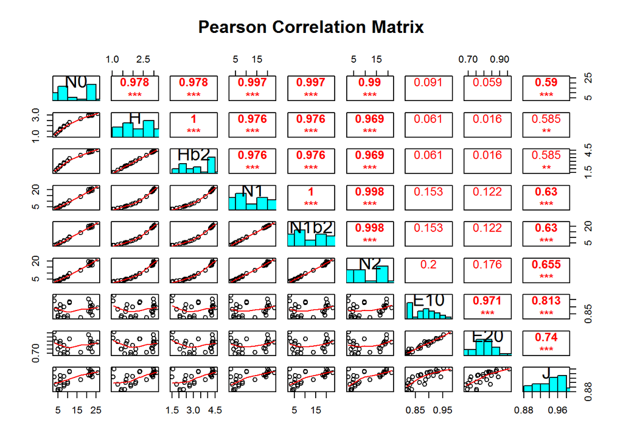

```r
# 绘制两两相关图
pairs(div[-1, ],
      lower.panel = panel.smooth,
      upper.panel = panel.cor,
      diag.panel = panel.hist, main = "Pearson Correlation Matrix"
      )
```

#### 8.2.3.2 甲螨群落的稀疏性分析(Rarefaction Analysis)

```r
# 稀疏性分析
# 物种的数量
(mite.nbsp <- specnumber(mite)) # Species richness (alternate)
```

```
##  1  2  3  4  5  6  7  8  9 10 11 12 13 14 15 16 17 18 19 20 21 22 23 24 25
## 20 23 19 23 19 21 16 21 16 19 25 19 18 23 18 17 14 18 21 20 16 14 15 13 19
## 26 27 28 29 30 31 32 33 34 35 36 37 38 39 40 41 42 43 44 45 46 47 48 49 50
## 17 22 18  9 21 15 16 16 21 18 18 16 14 11 12 11 10 12  5 17 16 14 12 13 11
## 51 52 53 54 55 56 57 58 59 60 61 62 63 64 65 66 67 68 69 70
## 14 12 15  8  9 11  5 11  7 12  9  6 16 13 13 14  6 13 17 15
```

```r
mite.nbsp[mite.nbsp == min(mite.nbsp)] # 提取物种丰富度的最小值
```

```
## 44 57
##  5  5
```

```r
mite.nbsp[mite.nbsp == max(mite.nbsp)] # 提取物种丰富度的最大值
```

```
## 11
## 25
```

```r
range(mite.nbsp) # 物种丰度的变化范围
```

```
## [1]  5 25
```

```r
(mite.abund <- rowSums(mite)) # Species richness
```

```
##   1   2   3   4   5   6   7   8   9  10  11  12  13  14  15  16  17  18
## 140 268 186 286 199 209 162 126 123 166 216 213 177 269 100  97  90 118
##  19  20  21  22  23  24  25  26  27  28  29  30  31  32  33  34  35  36
## 118 184 117 172  81  80 123 120 173 111 111  96 130  93 136 194 111 133
##  37  38  39  40  41  42  43  44  45  46  47  48  49  50  51  52  53  54
## 139 189  94 157  81 140 148  60 158 154 121 113 107 148  91 112 145  49
##  55  56  57  58  59  60  61  62  63  64  65  66  67  68  69  70
##  58 108   8 121  90 127  42  13  86  88 112 116 781 111 184 121
```

```r
range(mite.abund) # 总丰富度的变化范围
```

```
## [1]   8 781
```

```r
mite.abund[mite.nbsp == min(mite.nbsp)] # 提取物种丰富度的最小值
```

```
## 44 57
## 60  8
```

```r
mite.abund[mite.nbsp == max(mite.nbsp)] # 提取物种丰富度的最大值
```

```
##  11
## 216
```

```r
mite.nbsp[mite.abund == min(mite.abund)] # 提取物种丰富度的最小值
```

```
## 57
##  5
```

```r
mite.nbsp[mite.abund == max(mite.abund)] # 提取物种丰富度的最大值
```

```
## 67
##  6
```

```r
mite.rare80 <- rarefy(mite, sample = 80) # 甲螨数据集稀释成 80 个个体(样本)
# 比较排序结果 - 观察值与稀释值
sort(mite.nbsp)
```

```
## 44 57 62 67 59 54 29 55 61 42 39 41 50 56 58 40 43 48 52 60 24 49 64 65 68
##  5  5  6  6  7  8  9  9  9 10 11 11 11 11 11 12 12 12 12 12 13 13 13 13 13
## 17 22 38 47 51 66 23 31 53 70  7  9 21 32 33 37 46 63 16 26 45 69 13 15 18
## 14 14 14 14 14 14 15 15 15 15 16 16 16 16 16 16 16 16 17 17 17 17 18 18 18
## 28 35 36  3  5 10 12 25  1 20  6  8 19 30 34 27  2  4 14 11
## 18 18 18 19 19 19 19 19 20 20 21 21 21 21 21 22 23 23 23 25
```

```r
sort(round(mite.rare80))
```

```
## 67 44 57 62 59 29 54 42 55 61 40 43 48 50 56 58 60 22 38 39 41 52 31 47 65
##  4  5  5  6  7  8  8  9  9  9 10 10 10 10 10 10 10 11 11 11 11 11 12 12 12
## 68 13 17 24 33 45 49 51 53 64 66  7  9 12 21 26 37 46 70  2  3  4 23 25 36
## 12 13 13 13 13 13 13 13 13 13 13 14 14 14 14 14 14 14 14 15 15 15 15 15 15
## 69  5 15 16 18 28 32 34 35 63  1  6 10 20 27 14  8 11 19 30
## 15 16 16 16 16 16 16 16 16 16 17 17 17 17 17 18 19 19 19 19
```

```r
# Sites with estimated species richness
mite.rare80[mite.rare80 == min(mite.rare80)] # 稀释后的预估的物种丰富度最小值
```

```
##      67
## 3.83263
```

```r
mite.rare80[mite.rare80 == max(mite.rare80)] # 稀释后的预估的物种丰富度最小值
```

```
##      30
## 19.0877
```

```r
# Observed core with predicted species richness ??
mite[which(mite.rare80 == min(mite.rare80)),]
```

```
##    Brachysp Phthirsp Hoplcfpa Rhysardu Atrostri Protopsp Malacfeg Malacfpr
## 67        4        0        3        0        0        0        0        0
##    Malacosp Eniominu Hypochsp Nothprat Tectvela Oppinova Suctobsp Limncfci
## 67        0        0        0        0        0        0        0      723
##    Oribatsp Ceratsp1 Paracfwi Galumsp1 Stegasp2 Hyporufu Trhyposp Platpelt
## 67        0        0        0        0        0        0        7        0
##    Nanhcfco Schecfla Fuscseto Lepidosp Eupelops Galumsp2 Limncfru Protorsp
## 67        0        0        0        0        0        0       11        0
##    Ceratsp2 Oppcfmin Trimalsp
## 67        0        0       33
```

```r
mite[which(mite.rare80 == max(mite.rare80)),]
```

```
##    Brachysp Phthirsp Hoplcfpa Rhysardu Atrostri Protopsp Malacfeg Malacfpr
## 30       20        1        2        0        0        0        7        1
##    Malacosp Eniominu Hypochsp Nothprat Tectvela Oppinova Suctobsp Limncfci
## 30        0        0        0        1        6        6       10       18
##    Oribatsp Ceratsp1 Paracfwi Galumsp1 Stegasp2 Hyporufu Trhyposp Platpelt
## 30        1        2        2        1        0        0        1        0
##    Nanhcfco Schecfla Fuscseto Lepidosp Eupelops Galumsp2 Limncfru Protorsp
## 30        1        1        1        0        1        0       12        0
##    Ceratsp2 Oppcfmin Trimalsp
## 30        0        1        0
```

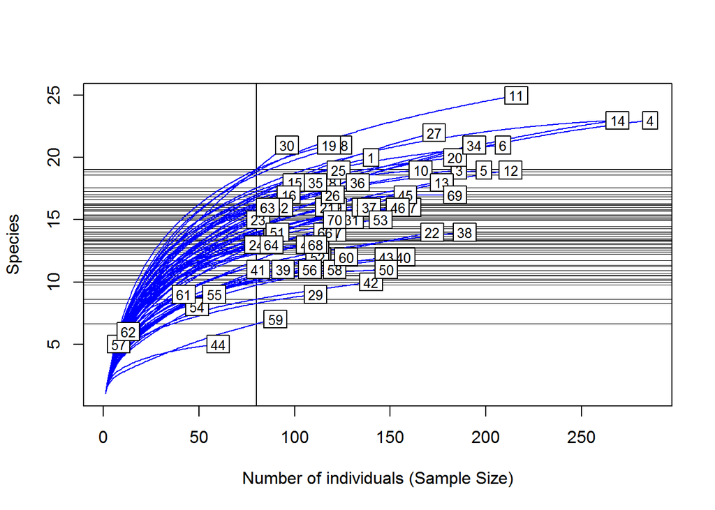

```r
# 稀释曲线 - Rarefaction curve
rarecurve(
  mite[-67,],  # 注意数据集
  step = 1,
  sample = 80,
  xlab = "Number of individuals (Sample Size)",
  ylab = "Species",
  label = TRUE,
  col = "blue"
  )
```

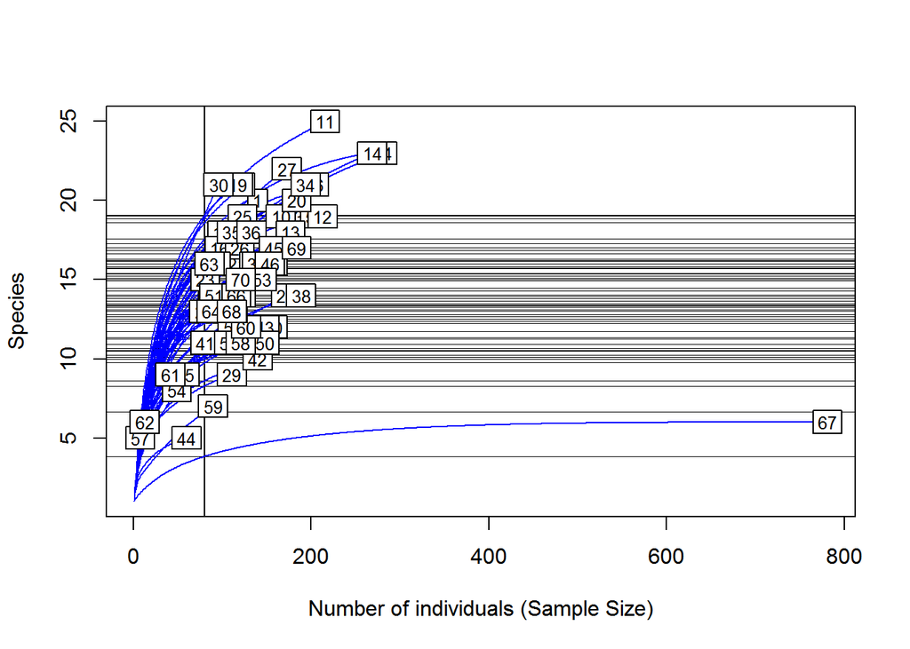

```r
rarecurve(
  mite,  # 注意数据集
  step = 1,
  sample = 80,
  xlab = "Number of individuals (Sample Size)",
  ylab = "Species",
  label = TRUE,
  col = "blue"
  )
```

## 8.3 与空间相关的多样性: Alpha, Beta and Gamma 多样性

## 8.4 β-多样性(Beta Diversity)

### 8.4.1 简单数字统计的β-多样性

```r
# Beta diversity, LCBD and SCBD of the fish data

# Gamma richness & 预期的物种池(expected species pool)
# ?specpool 估计物种库中外推的物种丰富度，或未观测物种的数量
# https://www.rdocumentation.org/packages/vegan/versions/2.4-2/topics/specpool
(gobs <- ncol(spe))
```

```
## [1] 27
```

```r
(gthe <- specpool(spe))
```

```
##     Species chao chao.se jack1 jack1.se jack2     boot    boot.se  n
## All      27   27       0    27        0    27 27.00062 0.02768511 29
```

```r
# 乘法分区 - Multiplicative partitioning of **Hill numbers** (Jost 2006, 2007)
# ?d
# Mean alpha species richness
d(spe, lev = "alpha", q = 0)
```

```
## [1] 12.93103
```

```r
# Mean alpha Shannon diversity
d(spe, lev = "alpha", q = 1)
```

```
## [1] 8.807188
```

```r
# Mean alpha Simpson diversity
d(spe, lev = "alpha", q = 2, boot = TRUE)
```

```
## $D.Value
## [1] 5.701004
##
## $StdErr
## [1] 0.1937163
```

```r
# 倍增 ? Multiplicative beta species richness
d(spe, lev = "beta", q = 0)
```

```
## [1] 2.088
```

```r
# 倍增 ? Multiplicative beta Shannon diversity
d(spe, lev = "beta", q = 1)
```

```
## [1] 2.24448
```

```r
# 倍增 ? Multiplicative beta Simpson diversity
d(spe, lev = "beta", q = 2, boot = TRUE)
```

```
## $D.Value
## [1] 2.660885
##
## $StdErr
## [1] 0.1356077
```

```r
# Gamma species richness
d(spe, lev = "gamma", q = 0)
```

```
## [1] 27
```

```r
# Gamma Shannon diversity
d(spe, lev = "gamma", q = 1)
```

```
## [1] 19.76756
```

```r
# Gamma Simpson diversity
d(spe, lev = "gamma", q = 2, boot = TRUE)
```

```
## $D.Value
## [1] 15.16971
##
## $StdErr
## [1] 0.5189723
```

```r
# 绘图 - multiplicative beta diversity vs order
mbeta <- data.frame(order = 0:20, beta = NA, se = NA)
for (i in 1:nrow(mbeta)) {
  out <- d(spe, lev = "beta", q = mbeta$order[i], boot = TRUE)
  mbeta$beta[i] <- out$D.Value
  mbeta$se[i] <- out$StdErr
  }

mbeta
```

```
##    order     beta         se
## 1      0 2.088000 0.03886484
## 2      1 2.244480 0.06902269
## 3      2 2.660885 0.14701228
## 4      3 3.333756 0.19090028
## 5      4 4.083607 0.29651793
## 6      5 4.746571 0.29457927
## 7      6 5.268541 0.28181085
## 8      7 5.665132 0.33851733
## 9      8 5.967177 0.38558095
## 10     9 6.200845 0.42150618
## 11    10 6.384976 0.39016821
## 12    11 6.532633 0.42622347
## 13    12 6.652902 0.41324258
## 14    13 6.752215 0.43644915
## 15    14 6.835219 0.44394808
## 16    15 6.905340 0.40218528
## 17    16 6.965154 0.47934966
## 18    17 7.016627 0.42216522
## 19    18 7.061282 0.45215276
## 20    19 7.100315 0.41979587
## 21    20 7.134671 0.49671207
```

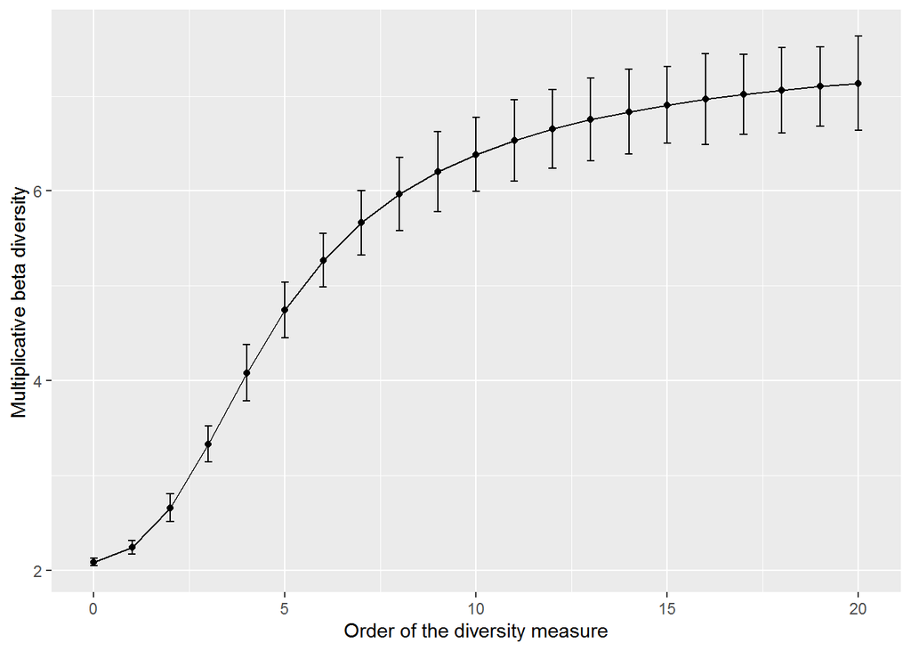

```r
ggplot(mbeta, aes(order, beta)) +
  geom_point() +
  geom_line() +
  geom_errorbar(
     aes(order, beta, ymin = beta - se, ymax = beta + se),
     width = 0.2) + labs(y = "Multiplicative beta diversity",
                         x = "Order of the diversity measure")
```

```r
# MacArthur's homogeneity 同质化 measure (MacArthur 1965)
# https://pdfs.semanticscholar.org/88c4/67e65b42eff088d19354632f41df6ca5804d.pdf
# https://rdrr.io/cran/vegetarian/man/M.homog.html
hom <- data.frame(order = 0:20, homogeneity = NA, se = NA)
for (i in 1:nrow(hom)) {
  out <- M.homog(spe, q = hom$order[i], std = TRUE, boot = TRUE)
  hom$homogeneity[i] <- out$M
  hom$se[i] <- out$StdErr
  }

hom
```

```
##    order homogeneity          se
## 1      0   0.4603175 0.006762558
## 2      1   0.4257353 0.009428594
## 3      2   0.3535225 0.014623898
## 4      3   0.2749606 0.016438138
## 5      4   0.2179130 0.013828304
## 6      5   0.1824883 0.009981520
## 7      6   0.1608704 0.009251160
## 8      7   0.1471083 0.009989832
## 9      8   0.1378543 0.008718663
## 10     9   0.1313136 0.010872993
## 11    10   0.1264969 0.009569047
## 12    11   0.1228304 0.011539616
## 13    12   0.1199643 0.009354871
## 14    13   0.1176745 0.008846951
## 15    14   0.1158119 0.010405032
## 16    15   0.1142732 0.009185091
## 17    16   0.1129851 0.010041786
## 18    17   0.1118943 0.008749084
## 19    18   0.1109608 0.011454590
## 20    19   0.1101545 0.009035521
## 21    20   0.1094521 0.009633093
```

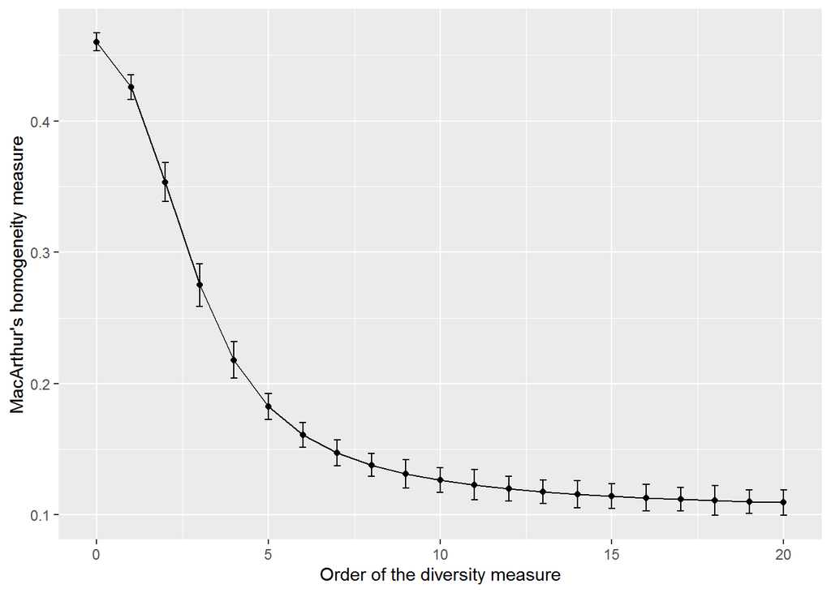

```r
ggplot(hom, aes(order, homogeneity)) +
  geom_point() +
  geom_line() +
  geom_errorbar(
     aes(order,
           homogeneity,
           ymin = homogeneity - se,
           ymax = homogeneity + se),
         width = 0.2) + labs(y = "MacArthur's homogeneity measure",
                             x = "Order of the diversity measure")
```

### 8.4.2 将 β-多样性作为群落组成表中的变量: SCBD & LCBD 指标

#### 8.4.2.1 简介

#### 8.4.2.2 计算 β-多样性

#### 8.4.2.3 关于β-多样性的相异性度量的性质(Properties of Dissimilarity Measures with Respect to Beta Diversity)

#### 8.4.2.4 β-多样性的局部贡献(Local Contributions to Beta Diversity, LCBD)

#### 8.4.2.5 β-多样性的物种贡献(Species Contributions to Beta Diversity, SCBD)

#### 8.4.2.6 使用 adespatial 分析包中的 beta.div() 函数计算 LCBD & SCBD

```r
# 对经过数据变化的群落物种数据进行 beta.div 统计
# https://www.rdocumentation.org/packages/adespatial/versions/0.3-4/topics/beta.div
# beta.div() 计算总β差异的估计值作为社区数据矩阵Y中的总方差
spe.beta <- beta.div(spe, method = "hellinger", nperm = 9999)
summary(spe.beta)
```

```
##        Length Class  Mode
## beta    2     -none- numeric
## SCBD   27     -none- numeric
## LCBD   29     -none- numeric
## p.LCBD 29     -none- numeric
## p.adj  29     -none- numeric
## method  2     -none- character
## note    1     -none- character
## D       1     -none- logical
```

```r
spe.beta$beta  # SSTotal and BDTotal
```

```
##    SStotal    BDtotal
## 14.0702872  0.5025103
```

```r
# species contributions to beta diversity (SCBD indices)
# local contributions of the sites to beta diversity (LCBD indices)
# Which species have a SCBD larger than the mean SCBD?
spe.beta$SCBD[spe.beta$SCBD >= mean(spe.beta$SCBD)]
```

```
##       Satr       Phph       Babl       Ruru       Alal
## 0.14229130 0.09491247 0.07129053 0.05494183 0.07964366
```

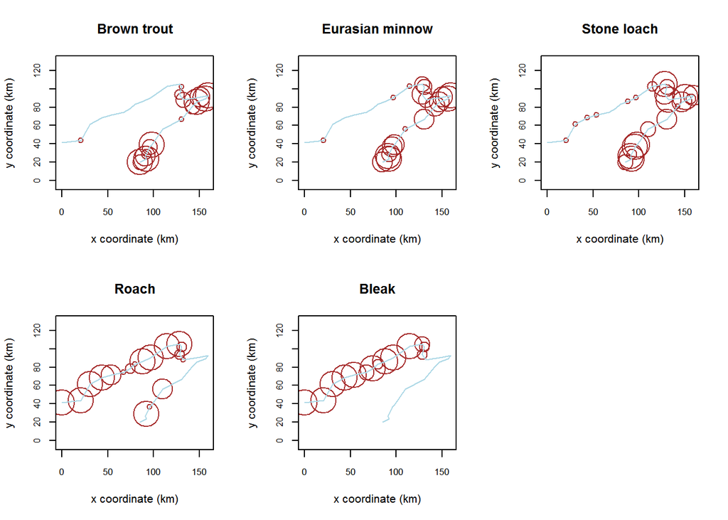

```r
### 不在本书中 --->>> ###
# 绘制 species with large SCBD
# species contributions to beta diversity (SCBD indices)
par(mfrow = c(2,3))
plot(spa,
     asp = 1,
     cex.axis = 0.8,
     col = "brown",
     cex = spe$Satr,
     main = "Brown trout",
     xlab = "x coordinate (km)",
     ylab = "y coordinate (km)"
     )
lines(spa, col = "light blue")
plot(spa,
     asp = 1,
     cex.axis = 0.8,
     col = "brown",
     cex = spe$Phph,
     main = "Eurasian minnow",
     xlab = "x coordinate (km)",
     ylab = "y coordinate (km)"
     )
lines(spa, col = "light blue")
plot(spa,
     asp = 1,
     cex.axis = 0.8,
     col = "brown",
     cex = spe$Babl,
     main = "Stone loach",
     xlab = "x coordinate (km)",
     ylab = "y coordinate (km)"
     )
lines(spa, col = "light blue")
plot(spa,
     asp = 1,
     cex.axis = 0.8,
     col = "brown",
     cex = spe$Ruru,
     main = "Roach",
     xlab = "x coordinate (km)",
     ylab = "y coordinate (km)"
     )
lines(spa, col = "light blue")
plot(spa,
     asp = 1,
     cex.axis = 0.8,
     col = "brown",
     cex = spe$Alal,
     main = "Bleak",
     xlab = "x coordinate (km)",
     ylab = "y coordinate (km)"
     )
lines(spa, col = "light blue")
### <<<--- 不在本书中 ###
```

```r
# local contributions of the sites to beta diversity (LCBD indices)
spe.beta$LCBD
```

```
##          1          2          3          4          5          6
## 0.07252040 0.04446478 0.04104101 0.02797626 0.02645407 0.01997878
##          7          9         10         11         12         13
## 0.03448857 0.04090284 0.03092578 0.03935674 0.03897281 0.04773390
##         14         15         16         17         18         19
## 0.03469917 0.02892282 0.02303320 0.01719880 0.01606821 0.01941901
##         20         21         22         23         24         25
## 0.02358674 0.02622679 0.03032694 0.06155305 0.05241202 0.04756547
##         26         27         28         29         30
## 0.03046571 0.03078689 0.03168996 0.02372550 0.03750379
```

```r
# p-values
spe.beta$p.LCBD
```

```
##      1      2      3      4      5      6      7      9     10     11
## 0.0001 0.0971 0.1847 0.8560 0.9110 0.9964 0.4983 0.1739 0.6866 0.2276
##     12     13     14     15     16     17     18     19     20     21
## 0.2255 0.0288 0.4145 0.7498 0.9628 0.9990 0.9999 0.9961 0.9578 0.9003
##     22     23     24     25     26     27     28     29     30
## 0.7279 0.0004 0.0098 0.0317 0.6906 0.6818 0.6249 0.9612 0.3074
```

```r
# Holm correction - p-value 校正
p.adjust(spe.beta$p.LCBD, "holm")
```

```
##      1      2      3      4      5      6      7      9     10     11
## 0.0029 1.0000 1.0000 1.0000 1.0000 1.0000 1.0000 1.0000 1.0000 1.0000
##     12     13     14     15     16     17     18     19     20     21
## 1.0000 0.7488 1.0000 1.0000 1.0000 1.0000 1.0000 1.0000 1.0000 1.0000
##     22     23     24     25     26     27     28     29     30
## 1.0000 0.0112 0.2646 0.7925 1.0000 1.0000 1.0000 1.0000 1.0000
```

```r
# 位点 - 显著性的 Holm-corrected LCBD value
row.names(spe[which(p.adjust(spe.beta$p.LCBD, "holm") <= 0.05),])
```

```
## [1] "1"  "23"
```

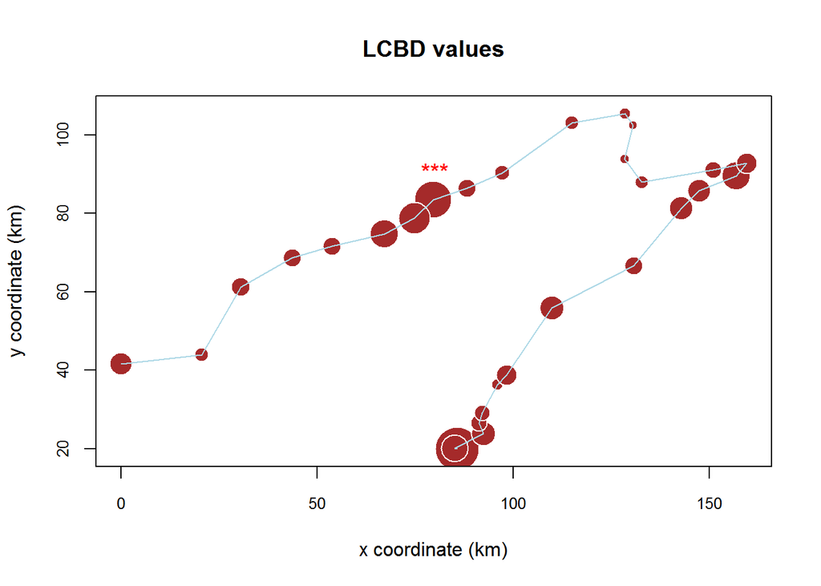

```r
# 在地图上进行绘制
plot(spa,
     asp = 1,
     cex.axis = 0.8,
     pch = 21,
     col = "white",
     bg = "brown",
     cex = spe.beta$LCBD * 70,
     main = "LCBD values",
     xlab = "x coordinate (km)",
     ylab = "y coordinate (km)"
     )
lines(spa, col = "light blue")
text(85, 11, "***", cex = 1.2, col = "red")
text(80, 92, "***", cex = 1.2, col = "red")
```

### 8.4.3 将β-多样性分解成替换 & 丰富度差异 & 嵌套组成(Replacement, Richness Difference and Nestedness Components)

#### 8.4.3.1 Podani 指数(Podani Family of Indices)

#### 8.4.3.2 Baselga 指数(Baselga Family of Indices)

#### 8.4.3.3 嵌套介绍(Flavours of Nestedness)

#### 8.4.3.4 使用 adespatial 分析包中的 beta.div.comp() 函数计算替换 & 丰富度差异 & 嵌套组成(Replacement & Richness Difference & Nestedness)

```r
# Jaccard-based Podani indices (presence-absence data)
# https://www.rdocumentation.org/packages/adespatial/versions/0.3-4/topics/beta.div.comp
# 分解
fish.pod.j <- beta.div.comp(spe, coef = "J", quant = FALSE)
summary(fish.pod.j)
```

```
##      Length Class  Mode
## repl 406    dist   numeric
## rich 406    dist   numeric
## D    406    dist   numeric
## part   5    -none- numeric
## Note   1    -none- character
```

```r
fish.pod.j$part
```

```
##         BDtotal            Repl         RichDif    Repl/BDtotal
##       0.3258676       0.0925460       0.2333216       0.2839988
## RichDif/BDtotal
##       0.7160012
```

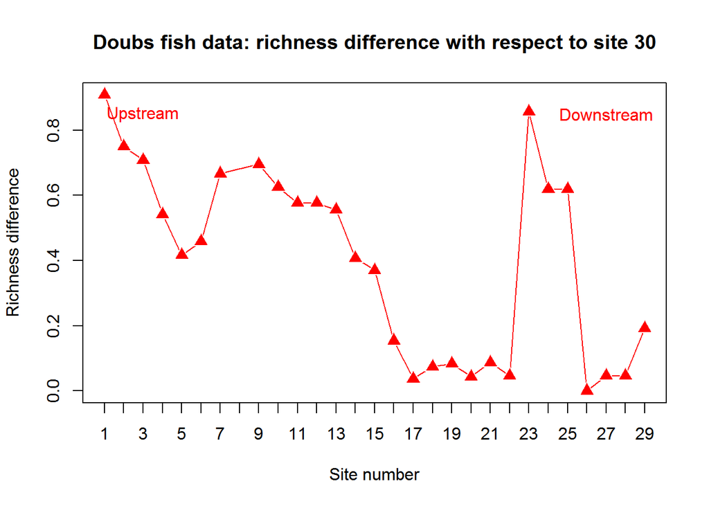

```r
# 提取丰富度差异矩阵 - Extraction of the richness difference matrix
fish.rich <- as.matrix(fish.pod.j$rich)
# 绘制丰富度差异 with respect to site 30
fish.rich.30 <- fish.rich[29, ][-29]
site.names <- seq(1, 29)[-8]
plot(site.names,
  fish.rich.30,
  type = "n",
  xaxp = c(1, 29, 28),
  main = "Doubs fish data: richness difference with respect to site 30",
  xlab = "Site number",
  ylab = "Richness difference"
  )
lines(site.names, fish.rich.30, pch = 24, col = "red")
points(
  site.names,
  fish.rich.30,
  pch = 24,
  cex = 1.5,
  col = "white",
  bg = "red"
  )
text(3, 0.85, "Upstream", cex = 1, col = "red")
text(27, 0.85, "Downstream", cex = 1, col = "red")
```

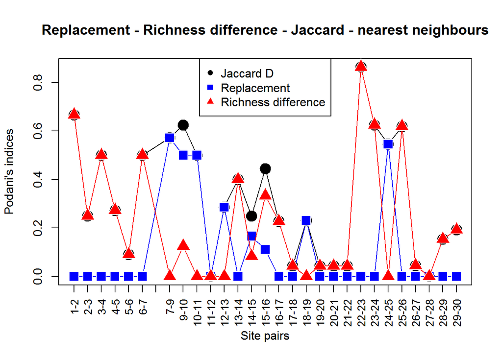

```r
# 提取替代矩阵 - Extraction of the replacement matrix
fish.repl <- as.matrix(fish.pod.j$repl)
# 提取相异矩阵 - Jaccard dissimilarity Dj matrix
fish.jac <- as.matrix(fish.pod.j$D)
# 绘图
# 首先，提取方差相异矩阵的子对角线
fish.repl.neigh <- diag(fish.repl[-1, ]) # Replacement
fish.rich.neigh <- diag(fish.rich[-1, ]) # Richness difference
fish.jac.neigh <- diag(fish.jac[-1, ]) # Jaccard Dj index
absc <- c(2:7, 9:30) # Abscissa
label.pairs <- c("1-2", "2-3", "3-4", "4-5", "5-6", "6-7", " ",
  "7-9", "9-10", "10-11", "11-12", "12-13", "13-14", "14-15",
  "15-16", "16-17", "17-18", "18-19", "19-20", "20-21", "21-22",
  "22-23", "23-24", "24-25", "25-26", "26-27", "27-28", "28-29",
  "29-30")
plot(
  absc,
  fish.jac.neigh,
  type = "n",
  xaxt = "n",
  main = "Replacement - Richness difference - Jaccard - nearest neighbours",
  xlab = "Site pairs",
  ylab = "Podani's indices"
  )
axis(side = 1, 2:30, labels = label.pairs, las = 2, cex.axis = 0.9)
lines(absc, fish.jac.neigh, col = "black")
points(
  absc,
  fish.jac.neigh,
  pch = 21,
  cex = 2,
  col = "black",
  bg = "black"
  )
lines(absc, fish.repl.neigh, col = "blue")
points(
  absc,
  fish.repl.neigh,
  pch = 22,
  cex = 2,
  col = "white",
  bg = "blue"
  )
lines(absc, fish.rich.neigh, col = "red")
points(
  absc,
  fish.rich.neigh,
  pch = 24,
  cex = 2,
  col = "white",
  bg = "red"
  )
legend(
  "top",
  c("Jaccard D", "Replacement", "Richness difference"),
  pch = c(16, 15, 17),
  col = c("black", "blue", "red")
  )
```

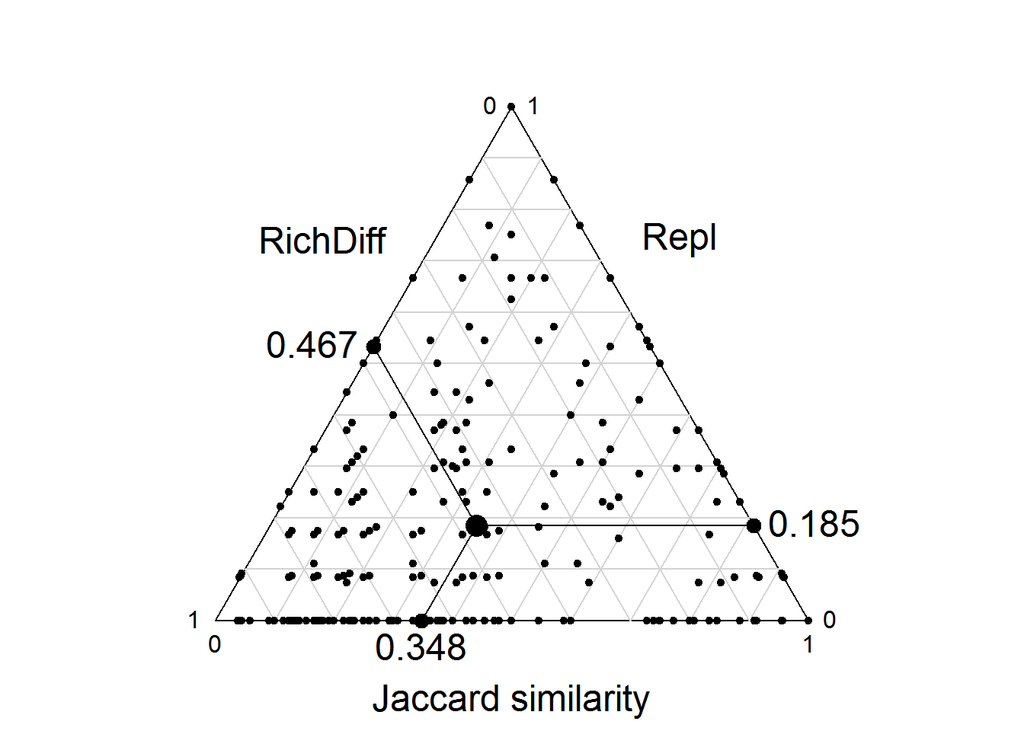

```r
# 三角绘图 - Triangular plots
# https://www.rdocumentation.org/packages/adespatial/versions/0.3-4/topics/beta.div.comp
# 分解
# Jaccard
fish.pod.J <- beta.div.comp(spe, coef = "J", quant = FALSE)
# Sorensen
fish.pod.S <- beta.div.comp(spe, coef = "S", quant = FALSE)
# Ruzicka
fish.pod.qJ <- beta.div.comp(spe, coef = "J", quant = TRUE)
# Percentage difference - 百分比差异
fish.pod.qS <- beta.div.comp(spe, coef = "S", quant = TRUE)
# 创建数据框
fish.pod.J.3 <- cbind((1 - fish.pod.J$D),
                      fish.pod.J$repl,
                      fish.pod.J$rich)
colnames(fish.pod.J.3) <- c("Similarity", "Repl", "RichDiff")
fish.pod.S.3 <- cbind((1 - fish.pod.S$D),
                      fish.pod.S$repl,
                      fish.pod.S$rich)
colnames(fish.pod.S.3) <- c("Similarity", "Repl", "RichDiff")
fish.pod.qJ.3 <- cbind((1 - fish.pod.qJ$D),
                       fish.pod.qJ$repl,
                       fish.pod.qJ$rich)
colnames(fish.pod.qJ.3) <- c("Similarity", "Repl", "AbDiff")
fish.pod.qS.3 <- cbind((1 - fish.pod.qS$D),
                       fish.pod.qS$repl,
                       fish.pod.qS$rich)
colnames(fish.pod.qS.3) <- c("Similarity", "Repl", "AbDiff")

# par(mfrow = c(2, 2))
triangle.plot(
  as.data.frame(fish.pod.J.3[, c(3, 1, 2)]),
  show = FALSE,
  labeltriangle = FALSE,
  addmean = TRUE
  )
text(-0.45,
     0.5,
     "RichDiff",
     cex = 1.5)
text(0.4,
     0.5,
     "Repl",
     cex = 1.5)
text(0,
     -0.6,
     "Jaccard similarity",
     cex = 1.5)
```

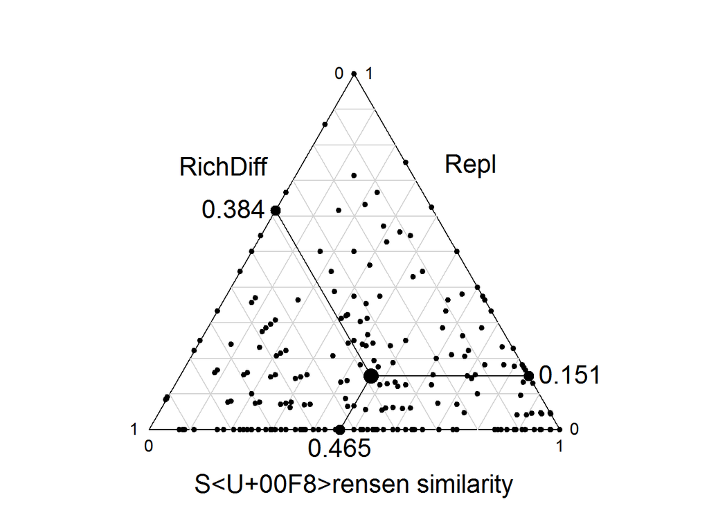

```r
triangle.plot(
  as.data.frame(fish.pod.S.3[, c(3, 1, 2)]),
  show = FALSE,
  labeltriangle = FALSE,
  addmean = TRUE
  )
text(-0.45,
     0.5,
     "RichDiff",
     cex = 1.5)
text(0.4,
     0.5,
     "Repl",
     cex = 1.5)
text(0,
     -0.6,
     "Sørensen similarity",
     cex = 1.5)
```

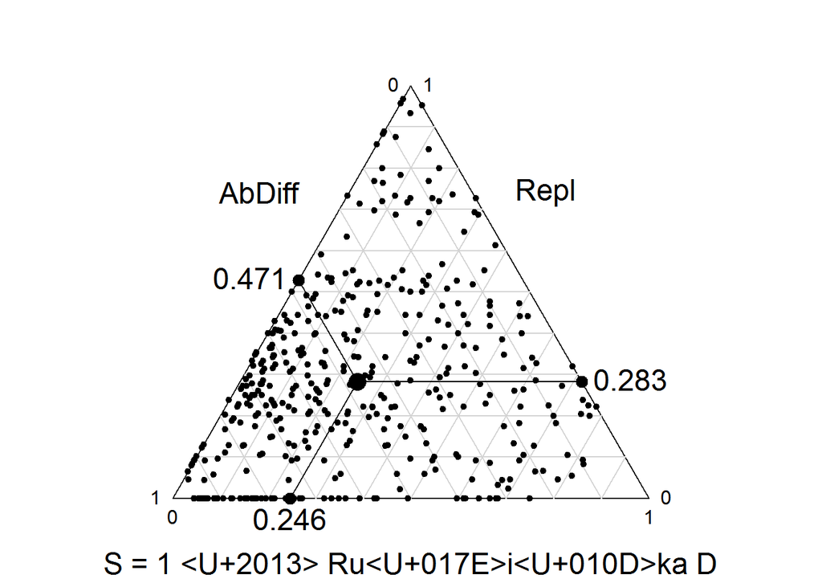

```r
triangle.plot(
  as.data.frame(fish.pod.qJ.3[, c(3, 1, 2)]),
  show = FALSE,
  labeltriangle = FALSE,
  addmean = TRUE
  )
text(-0.45,
     0.5,
     "AbDiff",
     cex = 1.5)
text(0.4,
     0.5,
     "Repl",
     cex = 1.5)
text(0,
     -0.6,
     "S = 1 – Ružička D",
     cex = 1.5)
```

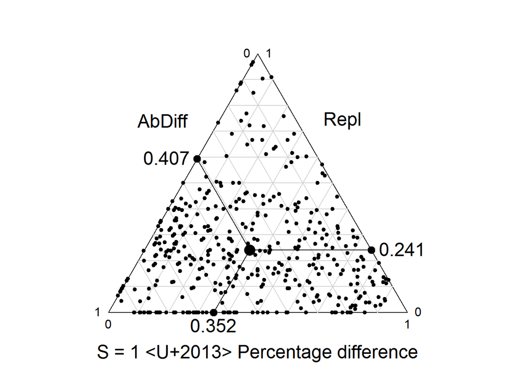

```r
triangle.plot(
  as.data.frame(fish.pod.qS.3[, c(3, 1, 2)]),
  show = FALSE,
  labeltriangle = FALSE,
  addmean = TRUE
  )
text(-0.45,
     0.5,
     "AbDiff",
     cex = 1.5)
text(0.4,
     0.5,
     "Repl",
     cex = 1.5)
text(0,
     -0.6,
     "S = 1 – Percentage difference",
     cex = 1.5)
```

```r
# 显示平均点的数值
colMeans(fish.pod.J.3[, c(3, 1, 2)])
```

```
##   RichDiff Similarity       Repl
##  0.4666431  0.3482649  0.1850920
```

```r
colMeans(fish.pod.S.3[, c(3, 1, 2)])
```

```
##   RichDiff Similarity       Repl
##  0.3836155  0.4652368  0.1511477
```

```r
colMeans(fish.pod.qJ.3[, c(3, 1, 2)])
```

```
##     AbDiff Similarity       Repl
##  0.4710724  0.2459779  0.2829498
```

```r
colMeans(fish.pod.qS.3[, c(3, 1, 2)])
```

```
##     AbDiff Similarity       Repl
##  0.4068776  0.3524080  0.2407143
```

#### 8.4.3.5 解释性替代与丰富度差异(Explaining Replacement and Richness Difference)

```r
# Replacement
# https://www.rdocumentation.org/packages/vegan/versions/2.4-2/topics/capscale
# [Partial] Distance-Based Redundancy Analysis
# [偏]基于距离的冗余分析
repl.dbrda <- dbrda(fish.repl ~ .,
                    data = env,
                    add = "cailliez")
anova(repl.dbrda)
```

[output not shown]

```r
RsquareAdj(repl.dbrda)
```

```
## $r.squared
## [1] 0.4159223
##
## $adj.r.squared
## [1] 0.03798962
```

```r
# Richness difference
# https://www.rdocumentation.org/packages/vegan/versions/2.4-2/topics/capscale
# [Partial] Distance-Based Redundancy Analysis
# [偏]基于距离的冗余分析
rich.dbrda <- dbrda(fish.rich ~ .,
                    data = env,
                    add = "cailliez")
anova(rich.dbrda)
```

```
## Permutation test for dbrda under reduced model
## Permutation: free
## Number of permutations: 999
##
## Model: dbrda(formula = fish.rich ~ dfs + ele + slo + dis + pH + har + pho + nit + amm + oxy + bod, data = env, add = "cailliez")
##          Df SumOfSqs      F Pr(>F)
## Model    11   23.799 1.5153  0.002 **
## Residual 17   24.272
## ---
## Signif. codes:  0 '***' 0.001 '**' 0.01 '*' 0.05 '.' 0.1 ' ' 1
```

```r
RsquareAdj(rich.dbrda)
```

```
## $r.squared
## [1] 0.4950798
##
## $adj.r.squared
## [1] 0.1683668
```

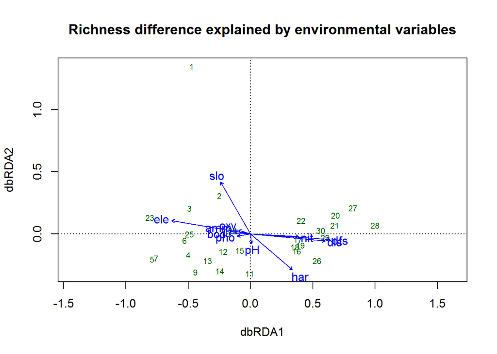

```r
plot(
  rich.dbrda,
  scaling = 1,
  display = c("lc", "cn"),
  main = "Richness difference explained by environmental variables"
  )
```

## 8.5 群落的功能性多样性 & 功能性组成 & 系统进化多样性

### 8.5.1 α-功能多样性(Alpha Functional Diversity)

```r
summary(fishtraits)
```

```
##       sort                        LatinName            Family
##  Min.   : 1.0   Abramis brama          : 1   Cyprinidae   :17
##  1st Qu.: 7.5   Alburnoides bipunctatus: 1   Percidae     : 2
##  Median :14.0   Alburnus alburnus      : 1   Salmonidae   : 2
##  Mean   :14.0   Ameiurus melas         : 1   Anguillidae  : 1
##  3rd Qu.:20.5   Anguilla anguilla      : 1   Centrarchidae: 1
##  Max.   :27.0   Barbatula barbatula    : 1   Cottidae     : 1
##                 (Other)                :21   (Other)      : 3
##          EnglishName              FrenchName   BodyLength
##  Barbel        : 1   Ablette           : 1   Min.   : 40.0
##  Black bullhead: 1   Anguille          : 1   1st Qu.: 85.0
##  Bleak         : 1   Barbeau fluviatile: 1   Median :180.0
##  Brown trout   : 1   Blageon           : 1   Mean   :196.7
##  Bullhead      : 1   Bouvi\350re          : 1   3rd Qu.:270.0
##  Common carp   : 1   Br\350me bordeli\350re  : 1   Max.   :600.0
##  (Other)       :21   (Other)           :21
##  BodyLengthMax     ShapeFactor      TrophicLevel      omnivory
##  Min.   :  70.0   Min.   : 2.410   Min.   :2.000   Min.   :0.0000
##  1st Qu.: 150.0   1st Qu.: 3.265   1st Qu.:2.845   1st Qu.:0.0000
##  Median : 360.0   Median : 4.330   Median :3.100   Median :1.0000
##  Mean   : 388.1   Mean   : 4.624   Mean   :3.166   Mean   :0.7037
##  3rd Qu.: 530.0   3rd Qu.: 5.015   3rd Qu.:3.495   3rd Qu.:1.0000
##  Max.   :1100.0   Max.   :16.670   Max.   :5.000   Max.   :1.0000
##
##   detritivory        herbivory       invertivory       piscivory
##  Min.   :0.00000   Min.   :0.0000   Min.   :0.0000   Min.   :0.0000
##  1st Qu.:0.00000   1st Qu.:0.0000   1st Qu.:1.0000   1st Qu.:0.0000
##  Median :0.00000   Median :0.0000   Median :1.0000   Median :0.0000
##  Mean   :0.03704   Mean   :0.2222   Mean   :0.9259   Mean   :0.2222
##  3rd Qu.:0.00000   3rd Qu.:0.0000   3rd Qu.:1.0000   3rd Qu.:0.0000
##  Max.   :1.00000   Max.   :1.0000   Max.   :1.0000   Max.   :1.0000
##
##    carnivory
##  Min.   :0.00000
##  1st Qu.:0.00000
##  Median :0.00000
##  Mean   :0.03704
##  3rd Qu.:0.00000
##  Max.   :1.00000
##
```

```r
rownames(fishtraits)
```

```
##  [1] "Cogo" "Satr" "Phph" "Babl" "Thth" "Teso" "Chna" "Pato" "Lele" "Sqce"
## [11] "Baba" "Albi" "Gogo" "Eslu" "Pefl" "Rham" "Legi" "Scer" "Cyca" "Titi"
## [21] "Abbr" "Icme" "Gyce" "Ruru" "Blbj" "Alal" "Anan"
```

```r
names(spe)
```

```
##  [1] "Cogo" "Satr" "Phph" "Babl" "Thth" "Teso" "Chna" "Pato" "Lele" "Sqce"
## [11] "Baba" "Albi" "Gogo" "Eslu" "Pefl" "Rham" "Legi" "Scer" "Cyca" "Titi"
## [21] "Abbr" "Icme" "Gyce" "Ruru" "Blbj" "Alal" "Anan"
```

```r
names(fishtraits)
```

```
##  [1] "sort"          "LatinName"     "Family"        "EnglishName"
##  [5] "FrenchName"    "BodyLength"    "BodyLengthMax" "ShapeFactor"
##  [9] "TrophicLevel"  "omnivory"      "detritivory"   "herbivory"
## [13] "invertivory"   "piscivory"     "carnivory"
```

```r
(tra <- fishtraits[ , 6:15])
```

```
##      BodyLength BodyLengthMax ShapeFactor TrophicLevel omnivory
## Cogo         80           120        3.13         3.10        0
## Satr        280           800        5.03         4.00        0
## Phph         60           100        2.95         3.10        1
## Babl         80           130        4.50         3.10        1
## Thth        300           450        4.33         3.10        0
## Teso         90           180        5.26         3.40        1
## Chna        280           480        6.50         2.00        1
## Pato        160           250        5.00         2.00        1
## Lele        180           360        2.81         2.57        1
## Sqce        240           500        3.97         3.50        1
## Baba        300           600        4.38         3.10        0
## Albi         80           110        4.21         2.90        1
## Gogo         90           130        4.00         3.10        0
## Eslu        600          1100        5.23         5.00        0
## Pefl        200           400        4.92         4.35        1
## Rham         40            70        2.68         2.50        1
## Legi         80           160        3.23         4.00        1
## Scer        180           400        3.58         2.50        1
## Cyca        360           800        2.71         2.40        1
## Titi        260           560        4.43         3.49        1
## Abbr        240           600        5.20         2.94        1
## Icme        180           280        5.83         3.70        1
## Gyce         80           150        3.64         3.10        0
## Ruru        200           400        4.95         2.79        1
## Blbj        160           360        3.30         3.10        1
## Alal         90           150        2.41         3.10        0
## Anan        420           840       16.67         3.53        1
##      detritivory herbivory invertivory piscivory carnivory
## Cogo           0         0           1         0         0
## Satr           0         0           1         1         0
## Phph           0         0           1         0         0
## Babl           0         0           1         0         0
## Thth           0         0           1         0         0
## Teso           0         0           1         0         0
## Chna           0         1           0         0         0
## Pato           0         1           0         0         0
## Lele           0         0           1         0         0
## Sqce           0         0           1         1         0
## Baba           0         0           1         0         0
## Albi           0         0           1         0         0
## Gogo           0         0           1         0         0
## Eslu           0         0           1         0         1
## Pefl           0         0           1         1         0
## Rham           0         1           1         0         0
## Legi           0         0           1         1         0
## Scer           0         1           1         0         0
## Cyca           0         0           1         0         0
## Titi           0         0           1         0         0
## Abbr           0         1           1         0         0
## Icme           0         0           1         1         0
## Gyce           0         0           1         0         0
## Ruru           0         1           1         0         0
## Blbj           1         0           1         0         0
## Alal           0         0           1         0         0
## Anan           0         0           1         1         0
```

```r
# 群落加权平均特征值 - Community-weighted mean trait values (CWMs)
# 功能性组成 - https://www.rdocumentation.org/packages/FD/versions/1.0-12/topics/functcomp
functcomp(tra,
          as.matrix(spe),
          CWM.type = "all")
```

```
##    BodyLength BodyLengthMax ShapeFactor TrophicLevel omnivory_0 omnivory_1
## 1    280.0000      800.0000    5.030000     4.000000  1.0000000  0.0000000
## 2    156.6667      399.1667    4.204167     3.475000  0.4166667  0.5833333
## 3    168.7500      390.6250    4.226875     3.500000  0.3750000  0.6250000
## 4    190.9524      406.6667    4.289048     3.609048  0.3333333  0.6666667
## 5    229.4118      461.7647    4.226471     3.422647  0.2352941  0.7647059
## 6    178.5714      379.0476    4.195238     3.413810  0.2380952  0.7619048
## 7    153.7500      369.3750    4.139375     3.373125  0.3125000  0.6875000
## 9    182.8571      367.8571    4.323571     3.182143  0.0000000  1.0000000
## 10   126.4286      255.0000    3.742143     3.145714  0.1428571  0.8571429
## 11   161.8182      363.6364    3.892727     3.381818  0.4545455  0.5454545
## 12   164.4444      364.4444    4.102222     3.372222  0.5000000  0.5000000
## 13   163.1579      353.1579    4.140526     3.368421  0.5263158  0.4736842
## 14   177.1429      358.9286    4.213214     3.375000  0.5357143  0.4642857
## 15   159.3939      328.1818    4.092121     3.245455  0.3939394  0.6060606
```

[output cut: 75 more lines]

### 8.5.2 β 分类学 & 系统发育学 & 功能性多样性(Beta Taxonomic, Phylogenetic and Functional Diversities)

```r
# 基于简化系统发育分类的距离矩阵
# 从物种列表中检索层次分类
splist <- as.character(fishtraits$LatinName)
# Database ncbi - less reliable than GBIF
spcla <- classification(splist, db = "ncbi")
```

[output not shown]

[output not shown]

[output not shown]

[output not shown]

[output not shown]

[output not shown]

[output not shown]

[output not shown]

[output not shown]

[output not shown]

[output not shown]

[output not shown]

[output not shown]

[output not shown]

[output not shown]

[output not shown]

[output not shown]

[output not shown]

[output not shown]

[output not shown]

[output not shown]

[output not shown]

[output not shown]

[output not shown]

[output not shown]

[output not shown]

[output not shown]

[output not shown]

[output not shown]

[output not shown]

[output not shown]

[output not shown]

[output not shown]

[output not shown]

[output not shown]

[output not shown]

[output not shown]

[output not shown]

[output not shown]

[output not shown]

[output not shown]

[output not shown]

[output not shown]

[output not shown]

[output not shown]

[output not shown]

[output not shown]

[output not shown]

[output not shown]

[output not shown]

[output not shown]

[output not shown]

[output not shown]

[output not shown]

[output not shown]

[output not shown]

[output not shown]

[output cut: 26 more lines]

[output not shown]

```r
# spcla <- classification(splist, db = "gbif") # 会报错

# 计算距离矩阵和系统发育树
# https://www.rdocumentation.org/packages/taxize/versions/0.9.7/topics/class2tree
# 将分类列表转换成树
tr <- class2tree(spcla)
tr$classification
```

```
##                                                 species            genus
## Cottus gobio                               Cottus gobio           Cottus
## Salmo trutta fario                         Salmo trutta            Salmo
## Phoxinus phoxinus                     Phoxinus phoxinus         Phoxinus
## Barbatula barbatula                 Barbatula barbatula        Barbatula
## Thymallus thymallus                 Thymallus thymallus        Thymallus
## Telestes souffia                       Telestes souffia         Telestes
## Chondrostoma nasus                   Chondrostoma nasus     Chondrostoma
## Parachondrostoma toxostoma   Parachondrostoma toxostoma Parachondrostoma
## Leuciscus leuciscus                 Leuciscus leuciscus        Leuciscus
## Squalius cephalus                     Squalius cephalus         Squalius
## Barbus barbus                             Barbus barbus           Barbus
## Alburnoides bipunctatus         Alburnoides bipunctatus      Alburnoides
## Gobio gobio                                 Gobio gobio            Gobio
## Esox lucius                                 Esox lucius             Esox
## Perca fluviatilis                     Perca fluviatilis            Perca
## Rhodeus amarus                           Rhodeus amarus          Rhodeus
## Lepomis gibbosus                       Lepomis gibbosus          Lepomis
## Scardinius erythrophthalmus Scardinius erythrophthalmus       Scardinius
## Cyprinus carpio                         Cyprinus carpio         Cyprinus
## Tinca tinca                                 Tinca tinca            Tinca
## Abramis brama                             Abramis brama          Abramis
## Ameiurus melas                           Ameiurus melas         Ameiurus
## Gymnocephalus cernua               Gymnocephalus cernua    Gymnocephalus
## Rutilus rutilus                         Rutilus rutilus          Rutilus
## Blicca bjoerkna                         Blicca bjoerkna           Blicca
## Alburnus alburnus                     Alburnus alburnus         Alburnus
## Anguilla anguilla                     Anguilla anguilla         Anguilla
##                               subfamily           family    suborder
## Cottus gobio                       <NA>         Cottidae  Cottioidei
## Salmo trutta fario           Salmoninae       Salmonidae        <NA>
## Phoxinus phoxinus                  <NA>       Cyprinidae Cyprinoidei
## Barbatula barbatula                <NA>    Nemacheilidae  Cobitoidei
## Thymallus thymallus         Thymallinae       Salmonidae        <NA>
## Telestes souffia                   <NA>       Cyprinidae Cyprinoidei
## Chondrostoma nasus                 <NA>       Cyprinidae Cyprinoidei
## Parachondrostoma toxostoma         <NA>       Cyprinidae Cyprinoidei
## Leuciscus leuciscus                <NA>       Cyprinidae Cyprinoidei
## Squalius cephalus                  <NA>       Cyprinidae Cyprinoidei
## Barbus barbus                      <NA>       Cyprinidae Cyprinoidei
```

[output cut: 337 more lines]

```
## Gobio gobio                 cellular organisms
## Esox lucius                 cellular organisms
## Perca fluviatilis           cellular organisms
## Rhodeus amarus              cellular organisms
## Lepomis gibbosus            cellular organisms
## Scardinius erythrophthalmus cellular organisms
## Cyprinus carpio             cellular organisms
## Tinca tinca                 cellular organisms
## Abramis brama               cellular organisms
## Ameiurus melas              cellular organisms
## Gymnocephalus cernua        cellular organisms
## Rutilus rutilus             cellular organisms
## Blicca bjoerkna             cellular organisms
## Alburnus alburnus           cellular organisms
## Anguilla anguilla           cellular organisms
```

```r
tr$distmat
```

```
##                             Cottus gobio Salmo trutta fario
## Salmo trutta fario             67.543018
## Phoxinus phoxinus              80.525811          80.525811
## Barbatula barbatula            80.525811          80.525811
## Thymallus thymallus            67.543018          25.410765
## Telestes souffia               80.525811          80.525811
## Chondrostoma nasus             80.525811          80.525811
## Parachondrostoma toxostoma     80.525811          80.525811
## Leuciscus leuciscus            80.525811          80.525811
## Squalius cephalus              80.525811          80.525811
## Barbus barbus                  80.525811          80.525811
## Alburnoides bipunctatus        80.525811          80.525811
## Gobio gobio                    80.525811          80.525811
## Esox lucius                    67.543018          43.524852
## Perca fluviatilis              37.960798          67.543018
## Rhodeus amarus                 80.525811          80.525811
## Lepomis gibbosus               50.016248          67.543018
## Scardinius erythrophthalmus    80.525811          80.525811
## Cyprinus carpio                80.525811          80.525811
## Tinca tinca                    80.525811          80.525811
## Abramis brama                  80.525811          80.525811
## Ameiurus melas                 80.525811          80.525811
## Gymnocephalus cernua           37.960798          67.543018
## Rutilus rutilus                80.525811          80.525811
## Blicca bjoerkna                80.525811          80.525811
## Alburnus alburnus              80.525811          80.525811
## Anguilla anguilla             100.000000         100.000000
##                             Phoxinus phoxinus Barbatula barbatula
## Salmo trutta fario
## Phoxinus phoxinus
## Barbatula barbatula                 37.960798
## Thymallus thymallus                 80.525811           80.525811
## Telestes souffia                    25.410765           37.960798
## Chondrostoma nasus                  25.410765           37.960798
## Parachondrostoma toxostoma          25.410765           37.960798
## Leuciscus leuciscus                 25.410765           37.960798
## Squalius cephalus                   25.410765           37.960798
## Barbus barbus                       25.410765           37.960798
## Alburnoides bipunctatus             25.410765           37.960798
## Gobio gobio                         25.410765           37.960798
```

[output cut: 269 more lines]

```
## Gobio gobio
## Esox lucius
## Perca fluviatilis
## Rhodeus amarus
## Lepomis gibbosus
## Scardinius erythrophthalmus
## Cyprinus carpio
## Tinca tinca
## Abramis brama
## Ameiurus melas
## Gymnocephalus cernua
## Rutilus rutilus
## Blicca bjoerkna
## Alburnus alburnus                 25.410765
## Anguilla anguilla                100.000000        100.000000
```

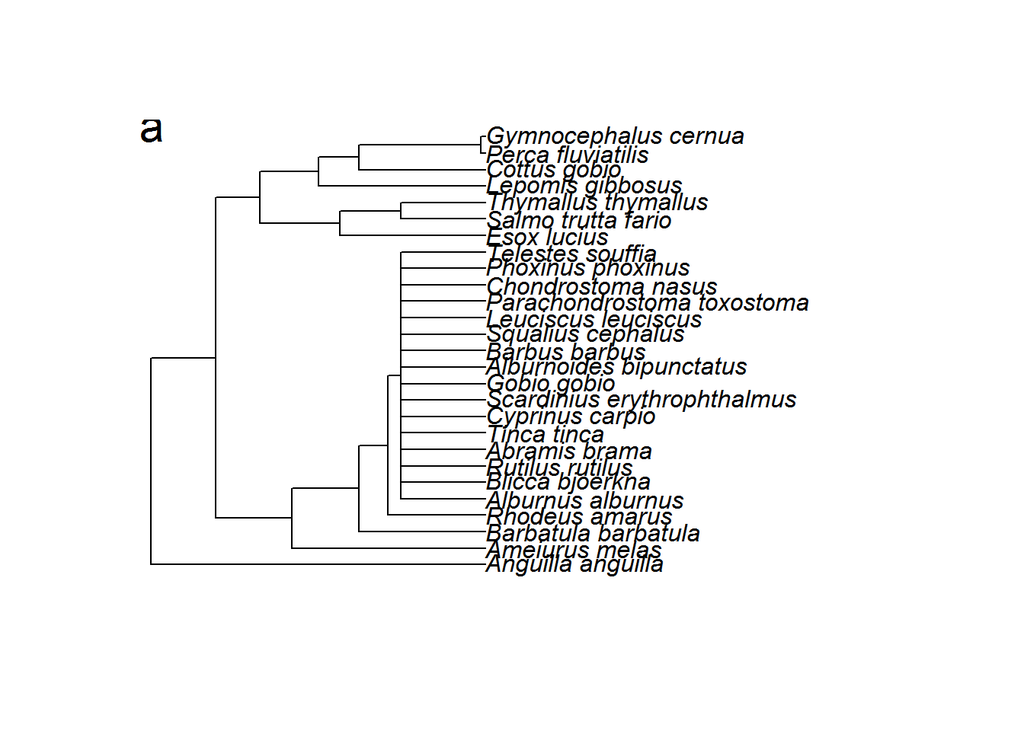

```r
# 将树转换为共生矩阵，约束在0和1之间
phylo.d <- cophenetic(tr$phylo) / 100
# 使用物种编码代替物种名 - Replace full species names by name codes
rownames(phylo.d) <- names(spe)
colnames(phylo.d) <- names(spe)

# 功能相异矩阵 - Functional dissimilarity matrix (Gower dissimilarity)
# https://www.rdocumentation.org/packages/FD/versions/1.0-12/topics/gowdis
# 产生相异矩阵
trait.d <- gowdis(tra, asym.bin = 5:10)
# 绘制树形图
trait.gw <- hclust(trait.d, "ward.D2")
# par(mfrow = c(1, 2))
plot(tr)
text(0.1, 27.5, "a", cex = 1.8)
```

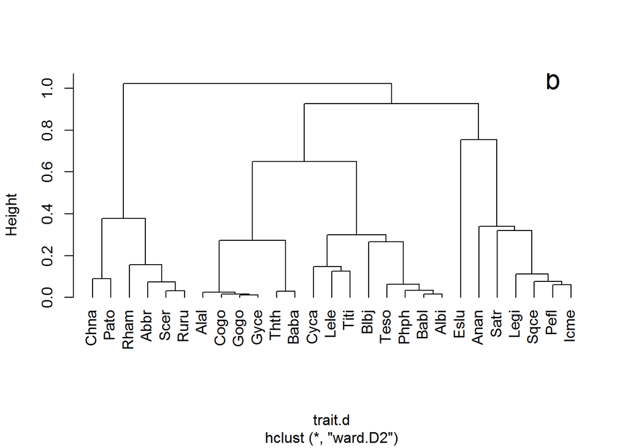

```r
plot(trait.gw,
     hang = -1,
     main = "")
text(26, 1.045, "b", cex = 1.8)
```

```r
# 添加分区 of TD, FD and PD (de Bello et al. 2010)
spe.rao <- Rao(
  sample = t(spe),
  dfunc = trait.d, # 可选的功能相异矩阵 - optional functional dissimilarity matrix
  dphyl = phylo.d, # 可选的系统发育距离矩阵 - optional phylogenetic distance matrix
  weight = FALSE,
  Jost = TRUE,
  structure = NULL
  )
names(spe.rao)
```

```
## [1] "TD" "FD" "PD"
```

```r
# 物种多样性 - Species diversity (Simpson)
names(spe.rao$TD)
```

```
##  [1] "Richness_per_plot"  "Relative_abundance" "Pi"
##  [4] "Wc"                 "Mean_Alpha"         "Alpha"
##  [7] "Gamma"              "Beta_add"           "Beta_prop"
## [10] "Pairwise_samples"
```

```r
# Mean alpha Simpson diversity
spe.rao$TD$Mean_Alpha
```

```
## [1] 5.701004
```

```r
# Gamma Simpson diversity
spe.rao$TD$Gamma
```

```
## [1] 15.16971
```

```r
# Additive beta Simpson diversity
spe.rao$TD$Beta_add
```

```
## [1] 9.46871
```

```r
spe.rao$TD$Gamma - spe.rao$TD$Mean_Alpha
```

```
## [1] 9.46871
```

```r
# Beta diversity expressed as percentage of gamma
spe.rao$TD$Beta_prop
```

```
## [1] 62.41851
```

```r
spe.rao$TD$Beta_add / spe.rao$TD$Gamma
```

```
## [1] 0.6241851
```

```r
# Multiplicative beta Simpson diversity
spe.rao$TD$Gamma / spe.rao$TD$Mean_Alpha
```

```
## [1] 2.660885
```

```r
# 系统多样性 - Phylogenetic diversity (Rao)
names(spe.rao$PD)
```

```
## [1] "Mean_Alpha"       "Alpha"            "Gamma"
## [4] "Beta_add"         "Beta_prop"        "Pairwise_samples"
```

```r
# Mean alpha Rao phylogenetic diversity
spe.rao$PD$Mean_Alpha
```

```
## [1] 1.769586
```

```r
# Gamma Rao phylogenetic diversity
spe.rao$PD$Gamma
```

```
## [1] 2.042401
```

```r
# Additive beta Rao phylogenetic diversity
spe.rao$PD$Beta_add
```

```
## [1] 0.2728147
```

```r
spe.rao$PD$Gamma - spe.rao$PD$Mean_Alpha
```

```
## [1] 0.2728147
```

```r
# Beta phylogenetic diversity expressed as percentage of gamma
spe.rao$PD$Beta_prop
```

```
## [1] 13.35755
```

```r
spe.rao$PD$Beta_add / spe.rao$PD$Gamma
```

```
## [1] 0.1335755
```

```r
# Multiplicative beta Rao phylogenetic diversity
spe.rao$PD$Gamma / spe.rao$PD$Mean_Alpha
```

```
## [1] 1.154169
```

```r
# 功能多样性 - Functional diversity (Rao)
names(spe.rao$FD)
```

```
## [1] "Mean_Alpha"       "Alpha"            "Gamma"
## [4] "Beta_add"         "Beta_prop"        "Pairwise_samples"
```

```r
# Mean alpha Rao functional diversity
spe.rao$FD$Mean_Alpha
```

```
## [1] 1.358419
```

```r
# Gamma Rao functional diversity
spe.rao$FD$Gamma
```

```
## [1] 1.425778
```

```r
# Additive beta Rao functional diversity
spe.rao$FD$Beta_add
```

```
## [1] 0.06735919
```

```r
spe.rao$FD$Gamma - spe.rao$FD$Mean_Alpha
```

```
## [1] 0.06735919
```

```r
# Beta functional diversity expressed as percentage of gamma
spe.rao$FD$Beta_prop
```

```
## [1] 4.724381
```

```r
spe.rao$FD$Beta_add / spe.rao$FD$Gamma
```

```
## [1] 0.04724381
```

```r
# Multiplicative beta Rao functional diversity
spe.rao$FD$Gamma / spe.rao$FD$Mean_Alpha
```

```
## [1] 1.049586
```

```r
# 方差 of alpha TD, PD, FD, 沿河
spe.rao$TD$Alpha
```

```
##         1         2         3         4         5         6         7
##  1.000000  2.880000  3.368421  5.727273  9.633333  7.000000  3.764706
##         9        10        11        12        13        14        15
##  3.769231  4.666667  4.172414  4.909091  5.084507  7.538462  9.637168
##        16        17        18        19        20        21        22
## 12.121212 16.689655 18.765957 16.531250 18.232558 19.220000 19.343284
##        23        24        25        26        27        28        29
##  2.666667  5.487805  6.368421 16.078261 17.484581 18.560606 21.687679
##        30
## 19.461916
```

```r
spe.rao$PD$Alpha
```

```
##        1        2        3        4        5        6        7        9
## 1.000000 1.833896 1.881853 2.091877 1.946041 1.849051 1.827642 1.296936
##       10       11       12       13       14       15       16       17
## 1.468148 2.019107 2.126866 2.109811 2.198084 1.931258 1.789012 1.842538
##       18       19       20       21       22       23       24       25
## 1.923554 1.615987 1.769487 1.857109 1.895538 1.188802 1.635446 1.626411
##       26       27       28       29       30
## 2.005835 2.024619 2.069381 2.150137 2.052116
```

```r
spe.rao$FD$Alpha
```

```
##        1        2        3        4        5        6        7        9
## 1.000000 1.322724 1.363995 1.399796 1.429789 1.335331 1.301813 1.218963
##       10       11       12       13       14       15       16       17
## 1.194670 1.330582 1.328871 1.321175 1.342251 1.285769 1.373304 1.416982
##       18       19       20       21       22       23       24       25
## 1.432009 1.396667 1.455410 1.480204 1.482724 1.311680 1.355598 1.367262
##       26       27       28       29       30
## 1.461999 1.493514 1.481915 1.505162 1.475582
```

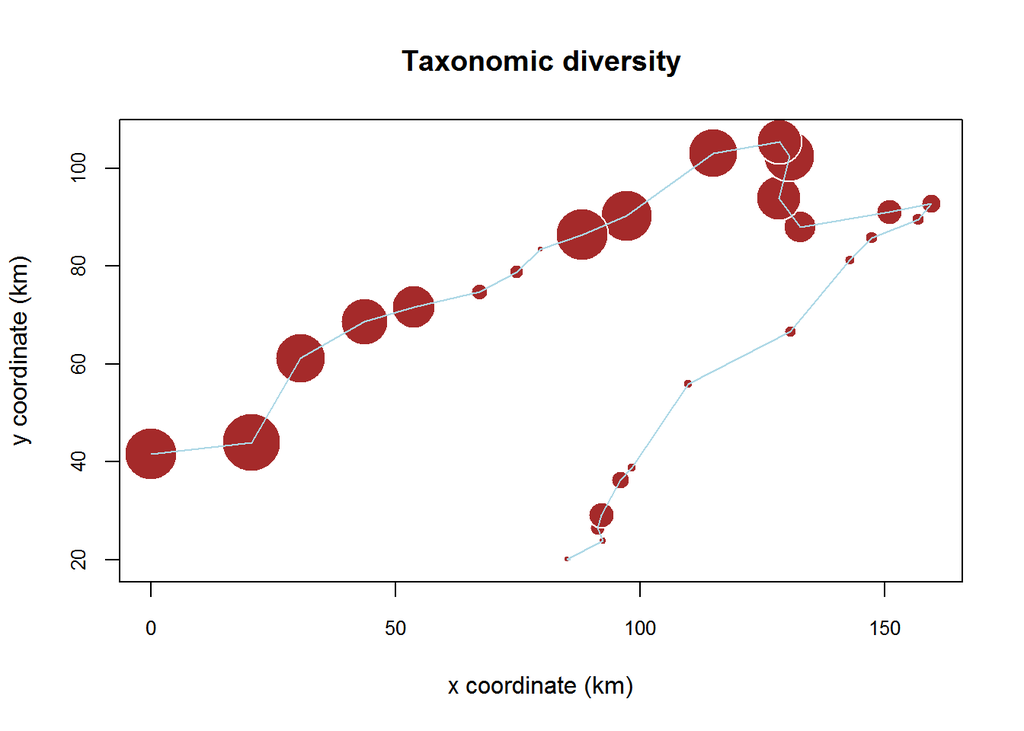

```r
# par(mfrow = c(2, 2))
plot(spa,
     asp = 1,
     cex.axis = 0.8,
     pch = 21,
     col = "white",
     bg = "brown",
     cex = spe.rao$TD$Alpha / 4,
     main = "Taxonomic diversity",
     xlab = "x coordinate (km)",
     ylab = "y coordinate (km)"
     )
lines(spa, col = "light blue")
```

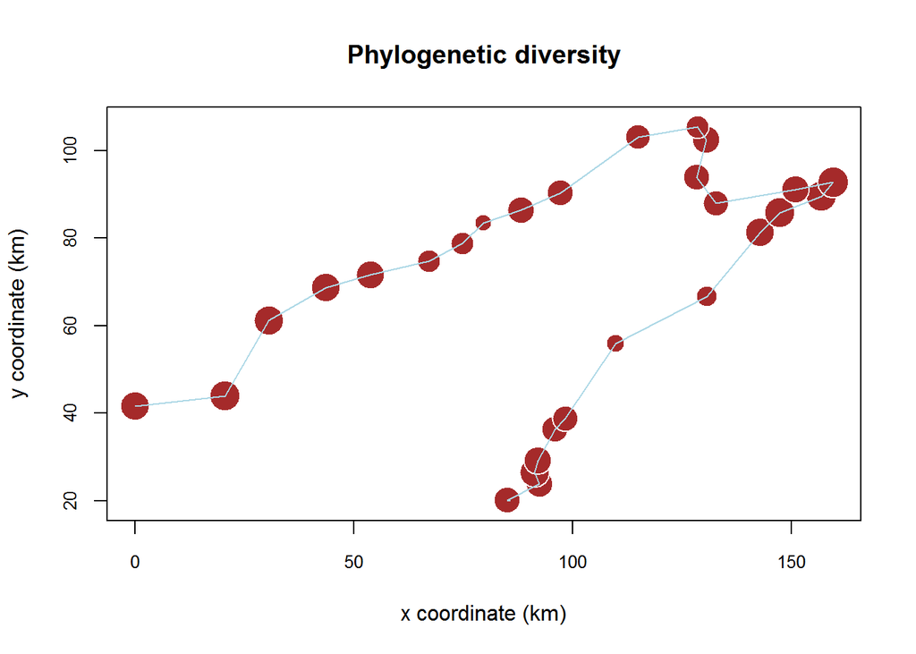

```r
plot(spa,
     asp = 1,
     cex.axis = 0.8,
     pch = 21,
     col = "white",
     bg = "brown",
     cex = spe.rao$PD$Alpha * 1.5,
     main = "Phylogenetic diversity",
     xlab = "x coordinate (km)",
     ylab = "y coordinate (km)"
     )
lines(spa, col = "light blue")
```

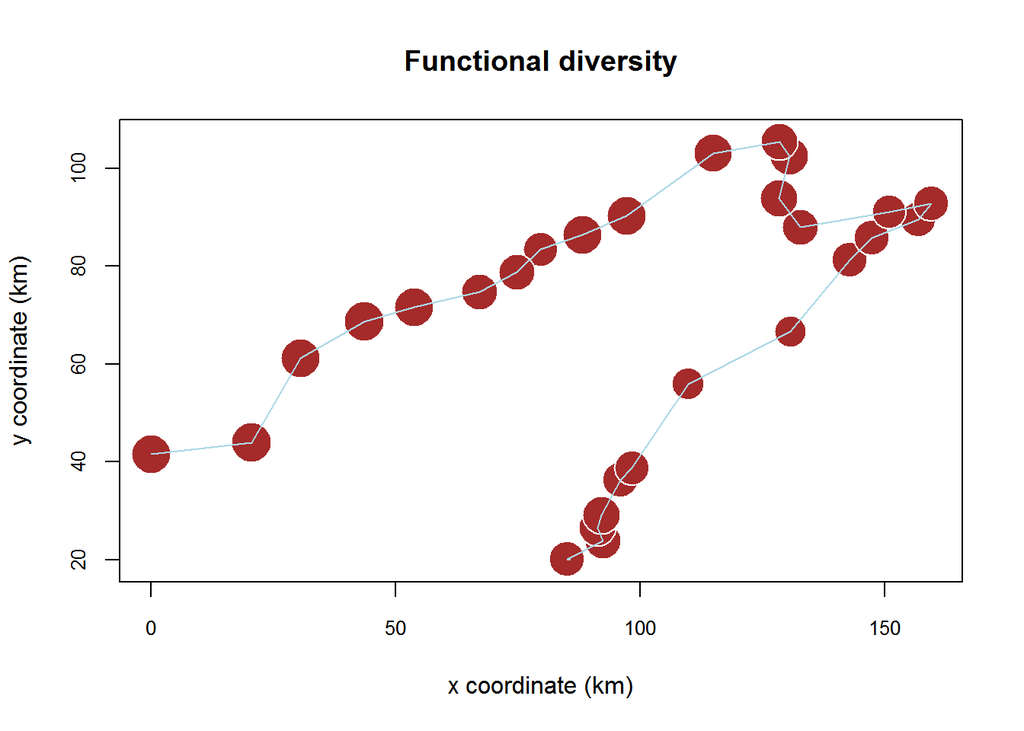

```r
plot(spa,
     asp = 1,
     cex.axis = 0.8,
     pch = 21,
     col = "white",
     bg = "brown",
     cex = spe.rao$FD$Alpha * 2.5,
     main = "Functional diversity",
     xlab = "x coordinate (km)",
     ylab = "y coordinate (km)"
     )
lines(spa, col = "light blue")
```

```r
# 添加 Rao-based 多样性指标
div$alphaTD <- spe.rao$TD$Alpha
div$alphaPD <- spe.rao$PD$Alpha
div$alphaFD <- spe.rao$FD$Alpha

# Save the div data frame as a CSV file
# write.csv(div, file = "diversity.csv", quote = FALSE)

# Save the species classification as a CSV file
# write.csv(tr$classification, file = "classification.csv", quote = FALSE)
```